# Multiomic data integration with MOFA2 model

```r
knitr::opts_chunk$set(warning = FALSE, message = FALSE)
library(MOFA2)
library(reticulate)
library(DESeq2)
library(sva)
library(MultiAssayExperiment)
library(tidyverse)
library(BiocParallel)
```

PREPARE MOFA2 MODEL

```r
#Load datasets
load("CLLdata/mofaCLL-main/data/gene.Rdata")
load("CLLdata/mofaCLL-main/data/rna.Rdata")
load("CLLdata/mofaCLL-main/data/meth.Rdata")
load("CLLdata/exprMat2.Rdata")
load("CLLdata/mofaCLL-main/data/drug.Rdata")
```

Prepare each single omic dataset

```r
#RNA sequencing
exprMat4 <- as.matrix(exprMat4)
exprMat4 <- assay(exprMat4)

##DNA methylation array
methData <- assays(meth)[["beta"]]
nTop = 5000
sds <- genefilter::rowSds(methData)
methData <- methData[order(sds, decreasing = T)[1:nTop],]

##Genetics
gene <- t(gene)

#Drug screening
viabMat <- mutate(drug, id = paste0(Drug,"_",concIndex)) %>%
  select(patientID, id, normVal) %>%
  spread(key = patientID, value = normVal) %>%
  data.frame() %>% column_to_rownames("id") %>%
  as.matrix()
```

Assemble multiAssayExperiment object

```r
#Create object
mofaData <- list(mRNA = exprMat4,
                 Mutations = gene,
                 Methylation = methData,
                 Drugs = viabMat)

# Create MultiAssayExperiment object
mofaData <- MultiAssayExperiment::MultiAssayExperiment(
  experiments = mofaData
)

#Only keep samples that have at least three assays
useSamples <- MultiAssayExperiment::sampleMap(mofaData) %>%
  as_tibble() %>% group_by(primary) %>% summarise(n= length(assay)) %>%
  filter(n >= 3) %>% pull(primary)
mofaData <- mofaData[,useSamples]
```

```r
#Dimensions for each dataset
experiments(mofaData)
```

```
ExperimentList class object of length 4:
 [1] mRNA: matrix with 5000 rows and 202 columns
 [2] Mutations: matrix with 39 rows and 217 columns
 [3] Methylation: matrix with 5000 rows and 158 columns
 [4] Drugs: matrix with 315 rows and 190 columns
```

```r
#How many samples have the complete datasets
table(table(sampleMap(mofaData)$primary))
```

```
  3   4
101 116
```

Build MOFA object from multiAssayExperiment object

```r
MOFAobject <- create_mofa(mofaData)
MOFAobject
```

```
Untrained MOFA model with the following characteristics:
 Number of views: 4
 Views names: mRNA Mutations Methylation Drugs
 Number of features (per view): 5000 39 5000 315
 Number of groups: 1
 Groups names: group1
 Number of samples (per group): 217
```

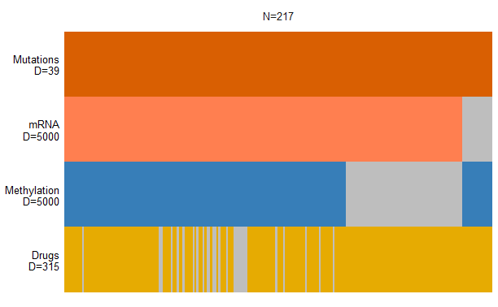

```r
plot_data_overview(MOFAobject)
```

Setup MOFA training parameters

```r
#Define data options
data_opts <- get_default_data_options(MOFAobject)
data_opts
```

```
$scale_views
[1] FALSE

$scale_groups
[1] FALSE

$center_groups
[1] TRUE

$use_float32
[1] TRUE

$views
[1] "mRNA"        "Mutations"   "Methylation" "Drugs"

$groups
[1] "group1"
```

Define model options

```r
model_opts <- get_default_model_options(MOFAobject)
model_opts$num_factors <- 30
model_opts
```

```
$likelihoods
       mRNA   Mutations Methylation       Drugs
 "gaussian"  "gaussian"  "gaussian"  "gaussian"

$num_factors
[1] 30

$spikeslab_factors
[1] FALSE

$spikeslab_weights
[1] FALSE

$ard_factors
[1] FALSE

$ard_weights
[1] TRUE
```

Define training options

```r
train_opts <- get_default_training_options(MOFAobject)
train_opts$convergence_mode <- "slow"
train_opts$seed <- 42
train_opts$maxiter <- 5000
train_opts$drop_factor_threshold <- 0.02
train_opts
```

```
$maxiter
[1] 5000

$convergence_mode
[1] "slow"

$drop_factor_threshold
[1] 0.02

$verbose
[1] FALSE

$startELBO
[1] 1

$freqELBO
[1] 5

$stochastic
[1] FALSE

$gpu_mode
[1] FALSE

$seed
[1] 42

$outfile
NULL

$weight_views
[1] FALSE

$save_interrupted
[1] FALSE
```

Run MOFA model

```r
MOFAobject <- prepare_mofa(
  object = MOFAobject,
  data_options = data_opts,
  model_options = model_opts,
  training_options = train_opts
)
```

```
Checking data options...
Checking training options...
Checking model options...
```

```r
MOFAobject <- run_mofa(MOFAobject, outfile = "MOFA_CLL.Rdata")
```

```
Connecting to the mofapy2 python package using reticulate (use_basilisk = FALSE)...
    Please make sure to manually specify the right python binary when loading R with reticulate::use_python(..., force=TRUE) or the right conda environment with reticulate::use_condaenv(..., force=TRUE)
    If you prefer to let us automatically install a conda environment with 'mofapy2' installed using the 'basilisk' package, please use the argument 'use_basilisk = TRUE'
```

[output not shown]

[output cut: 333 more lines]

```
Iteration 328: time=0.55, Factors=8
Iteration 329: time=0.57, Factors=8
Iteration 330: time=0.54, Factors=8
Iteration 331: time=0.58, ELBO=-1186006.40, deltaELBO=1.613 (0.00000462%), Factors=8

Converged!



#######################
## Training finished ##
#######################


Saving model in MOFA_CLL.Rdata...
```

Part 2. Overview of MOFA output

```r
load("CLLdata/mofaCLL-main/data/gene.Rdata")
load("CLLdata/mofaCLL-main/data/survival.Rdata")
load("CLLdata/reactomeGS2.Rdata")
load("CLLdata/mofaCLL-main/data/doublingTime.Rdata")
load("CLLdata/mofaCLL-main/data/demographic.Rdata")
```

```r
library(MOFA2)
library(tidyverse)
library(mltools)
library(survival)
library(survminer)
library(maxstat)
library(gridExtra)
library(car)
library(cowplot)
library(egg)
```

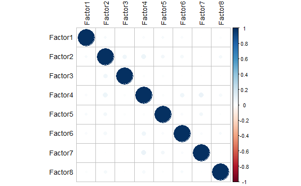

```r
plot_factor_cor(MOFAobject)
```

Variance explained by MOFA2 for each omic data

```r
# Calculate the variance explained (R2) per factor in each view
r2 <-calculate_variance_explained(MOFAobject)
r2$r2_total
```

```
$group1
       mRNA   Mutations Methylation       Drugs
   36.03633    20.15139    25.68467    13.40943

attr(,"class")
[1] "relistable" "list"
```

```r
r2$r2_per_factor
```

```
$group1
            mRNA    Mutations Methylation      Drugs
Factor1 8.194455 12.103509913 20.34483936 7.87233415
Factor2 4.997071  5.471872421  0.71173885 3.24817974
Factor3 7.363903  0.300539420  0.04433854 0.02841289
Factor4 2.096462  1.514198648  2.42370697 0.60676158
Factor5 6.431496  0.008640892  0.02938294 0.10342720
Factor6 2.688196  0.712371644  1.98685700 0.49213094
Factor7 2.555784  0.003360501  0.02259743 0.90978092
Factor8 2.154849  0.150784362  0.04492824 0.04636742

attr(,"class")
[1] "relistable" "list"
```

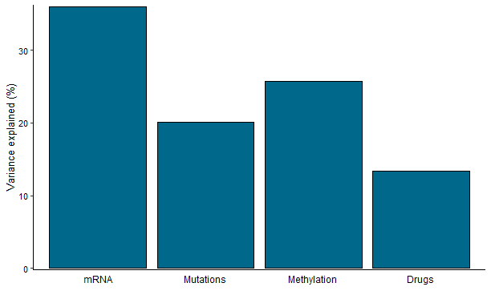

```r
#Total variance explained per view
plot_variance_explained(MOFAobject, plot_total = T)[[2]]
```

Variance explained per factor

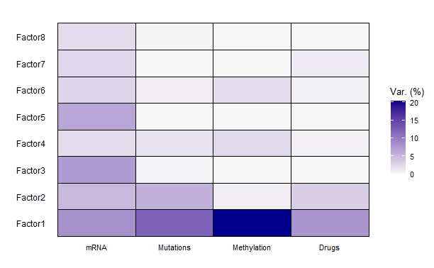

```r
varExpPlot <- plot_variance_explained(MOFAobject, censor = 0.25)
varExpPlot
```

Get weights and factors

```r
allWeights <- get_weights(MOFAobject,
                         views = "all",
                         factors = "all",
                         as.data.frame = TRUE) %>% as_tibble() %>%
  mutate(feature = ifelse(feature == "IGHV.status","IGHV",feature),
         factor = gsub("LF","F",factor))

allFactors <- get_factors(
  MOFAobject,
  factors = "all",
  as.data.frame = TRUE
) %>% as_tibble() %>%
  mutate(factor = gsub("LF","F", factor))

patAnno <- gene[c("IGHV", "trisomy12")] %>% data.frame() %>%
  rownames_to_column("sample") %>%
  filter(!is.na(IGHV),!is.na(trisomy12)) %>%
  mutate(IGHV = ifelse(IGHV==1, "M","U"),
         trisomy12 = ifelse(trisomy12 ==1, "yes","no"))

allFactors <- left_join(allFactors,
                        patAnno,
                        by = "sample")
```

Factor 1 Profile

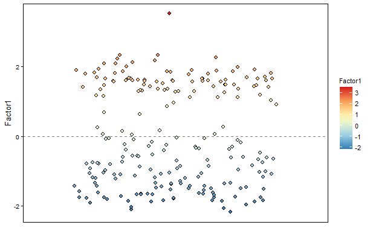

```r
plot_factor(MOFAobject,
            factors = 1,
            color_by = "Factor1"
)
```

Feature Weights

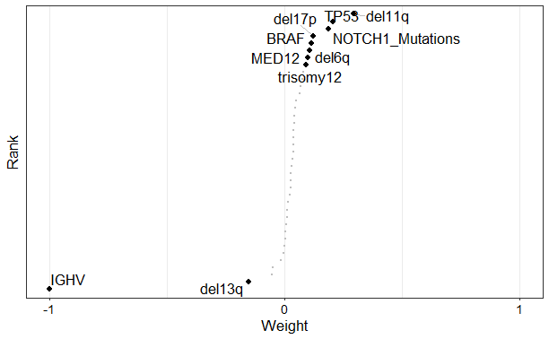

```r
#Factor1 Somatic Mutations
plot_weights(MOFAobject,
             view = "Mutations",
             factor = 1,
             nfeatures = 10,     # Top number of features to highlight
             scale = T           # Scale weights from -1 to 1
)
```

Loadings of genomic variations

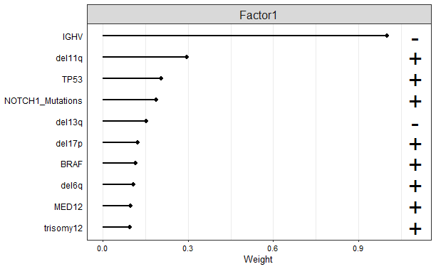

```r
plot_top_weights(MOFAobject,
                 view = "Mutations",
                 factor = 1,
                 nfeatures = 10,     # Top number of features to highlight
                 scale = T           # Scale weights from -1 to 1
)
```

Factor1 mRNA Expression

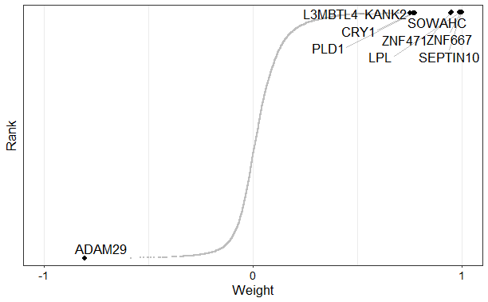

```r
plot_weights(MOFAobject,
             view = "mRNA",
             factor = 1,
             nfeatures = 10,
             scale = T
)
```

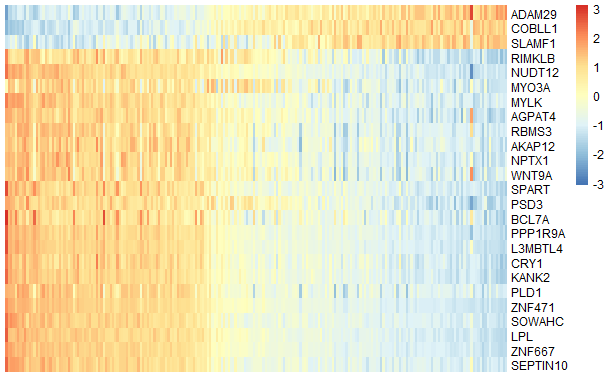

```r
#Heatap for the clusters of Factor1 gene expression
plot_data_heatmap(MOFAobject,
                  view = "mRNA",
                  factor = 1,
                  features = 25,
                  denoise = TRUE,
                  cluster_rows = FALSE, cluster_cols = FALSE,
                  show_rownames = TRUE, show_colnames = FALSE,
                  scale = "row"
)
```

Associations between Factor 1 and epigenetic subtypes

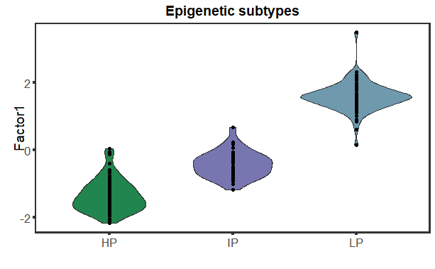

```r
#Methylation profile
plotTab <- filter(allFactors, factor %in% c("Factor1", "Factor2")) %>%
  mutate(Epitype = methCluster[sample]) %>%
  spread(key = factor ,value = value)

violinLF1_Meth <- ggplot(filter(plotTab, !is.na(Epitype)), aes(x=Epitype, y=Factor1, fill = Epitype)) +
  geom_violin() + geom_point() + scale_fill_manual(values = colList[4:length(colList)]) +
  theme_full + theme(legend.position = "none", axis.title.y = element_text(vjust=-2)) +
  xlab("") + ggtitle("Epigenetic subtypes")
violinLF1_Meth
```

Factor2 profile

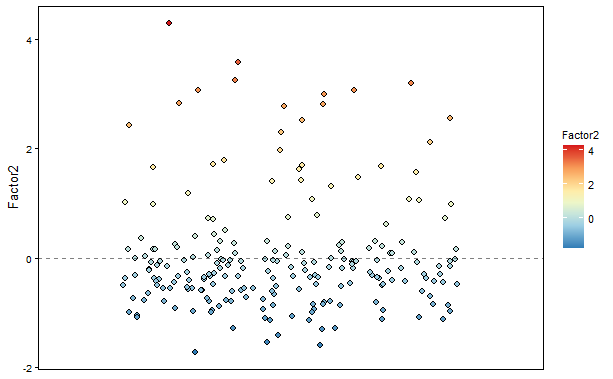

```r
plot_factor(MOFAobject,
            factors = 2,
            color_by = "Factor2"
)
```

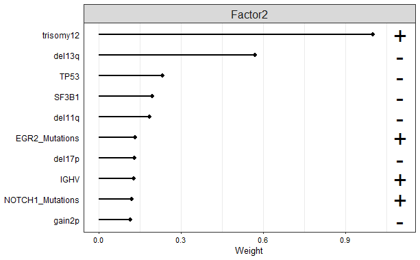

```r
plot_top_weights(MOFAobject,
                 view = "Mutations",
                 factor = 2,
                 nfeatures = 10,     # Top number of features to highlight
                 scale = T )
```

Plot the separation of the samples by the first two factors

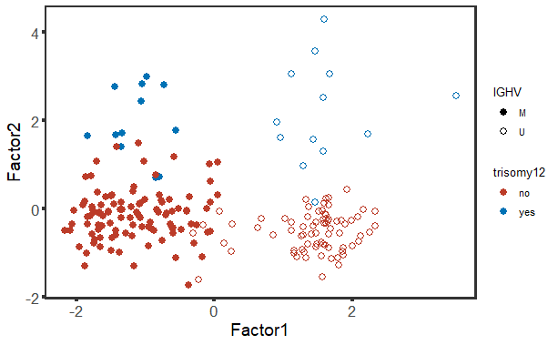

```r
plotTab <- filter(allFactors, factor %in% c("Factor1","Factor2")) %>%
  spread(key = factor, value = value) %>% mutate(trisomy12 = factor(trisomy12)) %>%
  filter(!is.na(IGHV), !is.na(trisomy12))

pcaLF1 <- ggplot(plotTab, aes(x=Factor1, y=Factor2, color = trisomy12,
                              shape = IGHV, label = sample)) +
  geom_point(size=3) +
  scale_shape_manual(values = c(M = 16, U =1)) +
  scale_color_manual(values = c(no = colList[1], yes = colList[2])) +
  theme_full
pcaLF1
```

Factor3 Profile

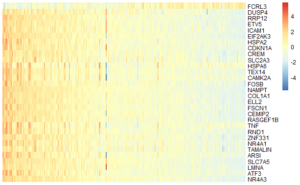

```r
plot_data_heatmap(MOFAobject,
                  view = "mRNA",
                  features = 30,
                  factor = 3,
                  denoise = TRUE,
                  cluster_rows = FALSE, cluster_cols = FALSE,
                  show_rownames = TRUE, show_colnames = FALSE,
                  scale = "row"
)
```

Factor 4 profile

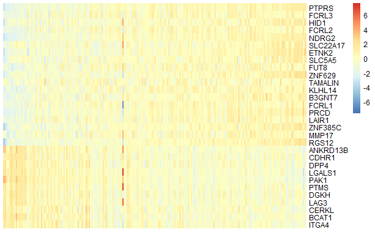

```r
plot_data_heatmap(MOFAobject,
                  view = "mRNA",
                  features = 30,
                  factor = 4,
                  denoise = TRUE,
                  cluster_rows = FALSE, cluster_cols = FALSE,
                  show_rownames = TRUE, show_colnames = FALSE,
                  scale = "row"
)
```

Factor 5 profile

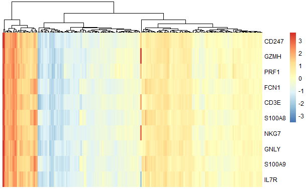

```r
plot_data_heatmap(MOFAobject,
                  view = "mRNA",
                  features = 10,
                  factor = 5,
                  denoise = TRUE,
                  cluster_rows = FALSE, cluster_cols = TRUE,
                  show_rownames = TRUE, show_colnames = FALSE,
                  scale = "row"
)
```

Assocations with RNAseq batch

```r
allFactors <- get_factors(
  MOFAobject,
  factors = "all",
  as.data.frame = TRUE
) %>% as_tibble() %>%
  mutate(factor = gsub("LF","F", factor))

batchTab <- filter(allFactors , factor == "Factor5") %>%
  mutate(batch = rna[,match(sample,colnames(rna))]$batch) %>%
  filter(!is.na(batch)) %>%
  mutate(batch = paste0("batch", batch+1))
```

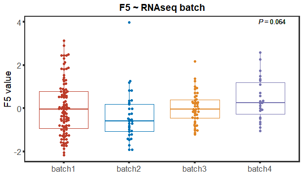

```r
pval <- car::Anova(lm(value ~ factor(batch), batchTab))$`Pr(>F)`[1]
pval <- formatNum(pval, digits = 2)
pAnno <- bquote(italic("P")~"="~.(pval))
colListNew <- colList[-4]
pL4 <- ggplot(batchTab, aes(x=batch, y = value, col = batch)) +
  geom_boxplot() +
  ggbeeswarm::geom_beeswarm() +
  scale_color_manual(values = colListNew) +
  annotate("text", x=Inf, y=Inf, label=pAnno, hjust=1.5, vjust=1.5)+
  theme_full +
  theme(legend.position = "none") +
  ylab("F5 value") + xlab("") + ggtitle("F5 ~ RNAseq batch")
pL4
```

Factor 6 profile

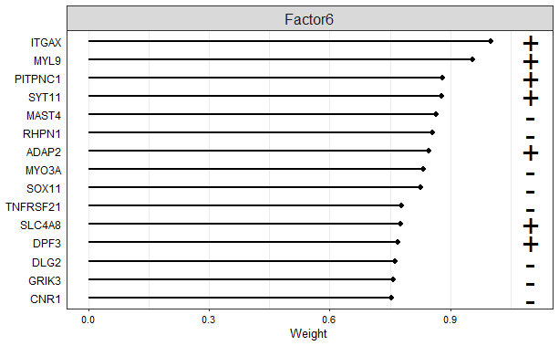

```r
plot_top_weights(MOFAobject,
                 view = "mRNA",
                 factor = 6,
                 nfeatures = 15, #Top number of features to highlight
                 scale = T           # Scale weights from -1 to 1
)
```

ASSOCIATIONS OF LATENT FACTORS TO CLINICAL BEHAVIORS

Univariate cox regression

```r
testTab <- left_join(allFactors, survival, by = c(sample = "patientID"))

#for OS
resOS <- filter(testTab, !is.na(OS)) %>%
  group_by(factor) %>%
  do(comSurv(.$value, .$OS, .$died, TRUE)) %>% ungroup() %>%
  arrange(p) %>% mutate(p.adj = p.adjust(p, method = "bonferroni")) %>%
  mutate(Endpoint = "OS")

#for TTT
resTTT <- filter(testTab, !is.na(TTT)) %>%
  group_by(factor) %>%
  do(comSurv(.$value, .$TTT, .$treatedAfter, TRUE)) %>% ungroup() %>%
  arrange(p) %>% mutate(p.adj = p.adjust(p, method = "bonferroni")) %>%
  mutate(Endpoint = "TTT")
```

Overall survival (OS)

```r
resOS
```

| factor | p | HR | lower | higher | p.adj | Endpoint |
| --- | --- | --- | --- | --- | --- | --- |
| Factor1 | 0.0006362655 | 1.8364350 | 1.2956929 | 2.602849 | 0.005090124 | OS |
| Factor4 | 0.0019453435 | 1.5858279 | 1.1846270 | 2.122905 | 0.015562748 | OS |
| Factor8 | 0.0967598379 | 1.2650816 | 0.9585238 | 1.669684 | 0.774078703 | OS |
| Factor3 | 0.1677946788 | 1.2397305 | 0.9135094 | 1.682448 | 1.000000000 | OS |
| Factor2 | 0.3282542099 | 0.8230293 | 0.5569806 | 1.216160 | 1.000000000 | OS |
| Factor7 | 0.6660116011 | 1.0896950 | 0.7377484 | 1.609540 | 1.000000000 | OS |
| Factor6 | 0.8140762622 | 0.9621270 | 0.6974087 | 1.327325 | 1.000000000 | OS |
| Factor5 | 0.8843897934 | 0.9764082 | 0.7077366 | 1.347073 | 1.000000000 | OS |

Time to treatment (TTT)

```r
resTTT
```

| factor | p | HR | lower | higher | p.adj | Endpoint |
| --- | --- | --- | --- | --- | --- | --- |
| Factor1 | 1.217468e-08 | 1.7920869 | 1.4662190 | 2.1903792 | 9.739743e-08 | TTT |
| Factor4 | 6.443294e-08 | 1.7148338 | 1.4102778 | 2.0851601 | 5.154635e-07 | TTT |
| Factor6 | 3.997652e-06 | 0.6740609 | 0.5700244 | 0.7970852 | 3.198121e-05 | TTT |
| Factor8 | 9.073873e-03 | 1.2381090 | 1.0545869 | 1.4535683 | 7.259098e-02 | TTT |
| Factor7 | 1.247127e-01 | 0.9071033 | 0.8009418 | 1.0273360 | 9.977016e-01 | TTT |
| Factor2 | 2.254036e-01 | 0.8762032 | 0.7076379 | 1.0849223 | 1.000000e+00 | TTT |
| Factor5 | 7.017514e-01 | 1.0369739 | 0.8611297 | 1.2487258 | 1.000000e+00 | TTT |
| Factor3 | 7.503101e-01 | 1.0303759 | 0.8569509 | 1.2388978 | 1.000000e+00 | TTT |

Plot p values and hazard ratios

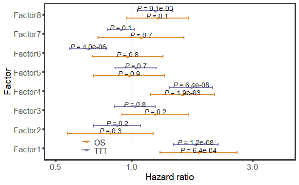

```r
plotTab <- bind_rows(resOS, resTTT) %>%
  filter(factor %in% c("Factor1","Factor2","Factor3", "Factor4", "Factor5", "Factor6", "Factor7", "Factor8"))

haPlot <- ggplot(plotTab, aes(x=factor, y = HR, col = Endpoint, dodge = Endpoint)) +
  geom_hline(yintercept = 1, linetype = "dotted") +
  geom_point(position = position_dodge(width=0.8)) +
  geom_errorbar(position = position_dodge(width =0.8),
                aes(ymin = lower, ymax = higher), width = 0.3, size=1) +
  geom_text(position = position_dodge2(width = 0.8),
            aes(x=as.numeric(as.factor(factor))+0.15,
                label = sprintf("italic(P)~'='~'%s'",
                                formatNum(p))),
            color = "black",size =4, parse =TRUE) +
  xlab("Factor") + ylab("Hazard ratio") +
  scale_y_log10(limits = c(0.5,4)) +
  coord_flip() + theme_full + theme(legend.title = element_blank(),
                                    legend.position = c(0.2,0.1),
                                    legend.background = element_blank(),
                                    legend.key.size = unit(0.5,"cm"),
                                    legend.key.width = unit(0.6,"cm"),
                                    legend.text = element_text(size=rel(1.2))) +
  scale_color_manual(values = c(OS = colList[3], TTT = colList[5], TFT = colList[4]))
haPlot
```

Kaplan-Meiler plots

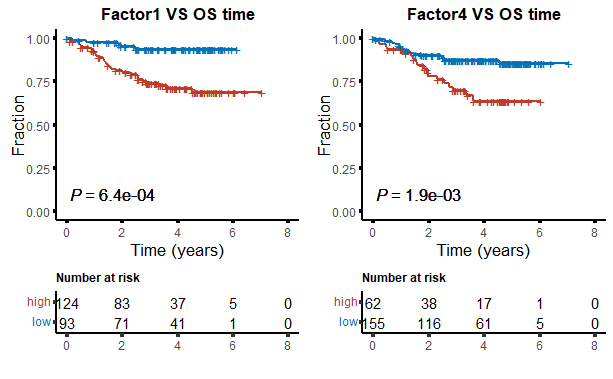

```r
#KM plot for overall survival (OS)
facList <- sort(filter(resOS, p<=0.05)$factor)
osList <- lapply(facList, function(x) {
  eachTab <- filter(testTab, factor == x) %>%
    select(value, OS, died) %>% filter(!is.na(OS))
  pval <- filter(resOS, factor == x)$p
  km(eachTab$value, eachTab$OS, eachTab$died, sprintf("%s VS OS time", x),
     stat = "maxstat", pval = pval, showTable = TRUE)
})
grid.arrange(grobs = osList, ncol = 2)
```

KM plot for time to treatment (TTT)

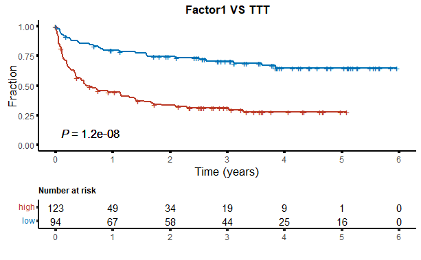

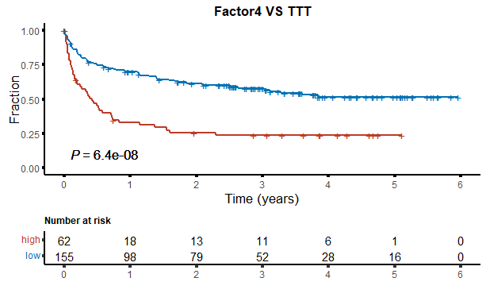

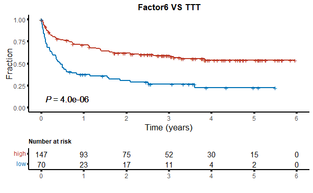

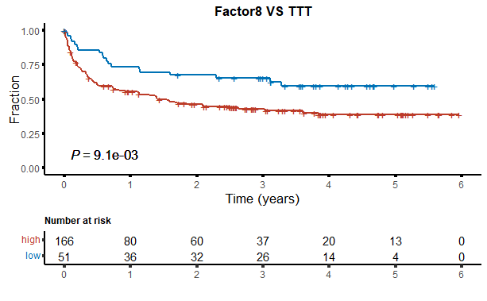

```r
facList <- sort(filter(resTTT, p<=0.01)$factor)
tttList <- lapply(facList, function(x) {
  eachTab <- filter(testTab, factor == x) %>%
    select(value, TTT, treatedAfter) %>% filter(!is.na(TTT))
  pval <- filter(resTTT, factor == x)$p
  km(eachTab$value, eachTab$TTT, eachTab$treatedAfter, sprintf("%s VS TTT", x), stat = "maxstat",
     maxTime = 7, pval = pval, showTable = TRUE)
})
tttList
```

KM plot for subgroup defined by IGHV status and median latent factor values

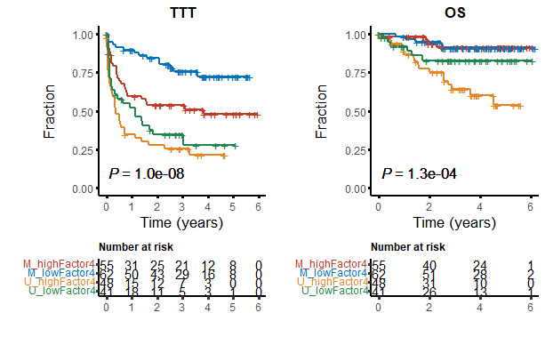

```r
groupTab <- filter(testTab, factor == "Factor4", !is.na(value), !is.na(IGHV)) %>%
  mutate(subgroup = ifelse(value > median(value), paste0(IGHV,"_highFactor4"), paste0(IGHV,"_lowFactor4")))

plotList <- list()

# TTT
plotList[["TTT"]] <- km(groupTab$subgroup, groupTab$TTT, groupTab$treatedAfter, "TTT", stat = "binary", maxTime = 7, showP = TRUE, showTable = TRUE, yLabelAdjust = -10)
#OS
# OS
plotList[["OS"]] <- km(groupTab$subgroup, groupTab$OS, groupTab$died, "OS", stat = "binary", maxTime = 7, showP = TRUE, showTable = TRUE, yLabelAdjust = -10)
grid.arrange(grobs = plotList, ncol = 2)
```

Multi-variate Cox regression for Factor 4

```r
#Prepare data for multi-variate Cox regression
survTab <- survival
facTab <- filter(allFactors, factor == "Factor4")
riskTab <- gene[,c("IGHV","TP53","NOTCH1","del17p","SF3B1")] %>%
  data.frame() %>% rownames_to_column("patientID") %>%
  mutate(`TP53.del17p` = as.numeric(TP53 | del17p)) %>%
  select(-TP53, -del17p) %>%
  mutate_if(is.numeric, as.factor) %>%
  left_join(select(demographic, patientID, age, sex), by = "patientID") %>%
  mutate(age = age/10) %>%
  mutate(F4 = facTab[match(patientID, facTab$sample),]$value,
         IGHV = factor(IGHV, levels = c(0,1))) %>%
  dplyr::rename(IGHV_mutated = IGHV, Sex_male = sex, Age = age) %>%
  filter(!is.na(F4))
```

Time to treatment

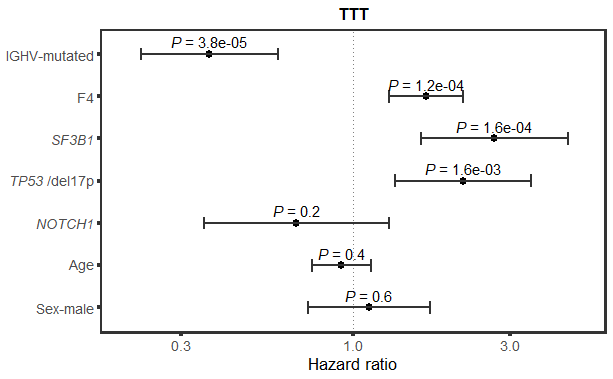

```r
resTTT <- runCox(survTab, riskTab, "TTT", "treatedAfter")
#summary(surv1)
haTTT <- plotHazard(resTTT, title = "TTT") +
  scale_y_log10(limits=c(0.2,5))
haTTT
```

Overall survival

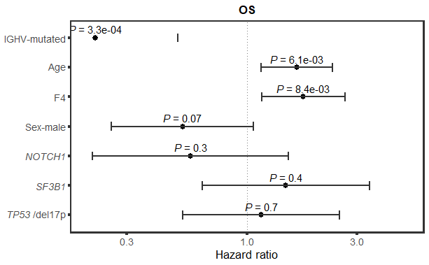

```r
resOS <- runCox(survTab, riskTab, "OS", "died")
#summary(surv1)
haOS <- plotHazard(resOS, title = "OS") +
  scale_y_log10(limits=c(0.2,5))
haOS
```

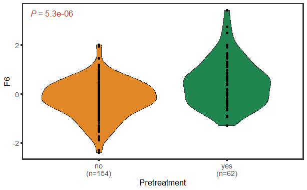

```r
#Pretreatment
plotTab <- left_join(demographic, facTab, by = c(patientID = "sample")) %>%
  filter(!is.na(value)) %>%
  mutate(pretreat = ifelse(is.na(pretreat),NA,
                           ifelse(pretreat ==1 , "yes","no")),
         sex = ifelse(is.na(sex),NA,
                           ifelse(sex =="f" , "Female","Male")))

corRes <- t.test(value ~ pretreat, plotTab)
annoP <- paste("italic(P)~'='~",formatNum(corRes$p.value, digits = 1, format = "e"))

plotTab <- filter(plotTab, !is.na(pretreat)) %>%
  group_by(pretreat) %>% mutate(n=n()) %>% ungroup() %>%
  mutate(pretreat = sprintf("%s\n(n=%s)",pretreat,n))

plotTreat <- ggplot(filter(plotTab,!is.na(pretreat)), aes(x = pretreat, y = value)) +
  geom_violin(aes(fill = pretreat)) +
  geom_point() +
  annotate("text", x = -Inf, y = Inf, label = annoP,
           hjust=-0.2, vjust =2, size = 5, parse = TRUE, col= colList[1]) +
  scale_fill_manual(values = colList[3:length(colList)]) +
  ylab("F6") + xlab("Pretreatment") +
  theme_full + theme(legend.position = "none")
plotTreat
```

Association between F4 and outcomes in treatment-naive patients

Univariate Cox regression

```r
survival.untreated <- survival %>% mutate(pretreat = demographic[match(patientID, demographic$patientID),]$pretreat) %>%
  filter(pretreat ==0)
testTab <- left_join(allFactors, survival.untreated, by = c(sample = "patientID"))

#for OS
resOS <- filter(testTab, !is.na(OS), factor == "Factor4") %>%
  group_by(factor) %>%
  do(comSurv(.$value, .$OS, .$died, TRUE)) %>% ungroup() %>%
  arrange(p) %>% mutate(p.adj = p.adjust(p, method = "BH")) %>%
  mutate(Endpoint = "OS")

resOS
```

| factor | p | HR | lower | higher | p.adj | Endpoint |
| --- | --- | --- | --- | --- | --- | --- |
| Factor4 | 0.4396614 | 1.259458 | 0.7015969 | 2.260893 | 0.4396614 | OS |

```r
NA
```

```r
#for TTT
resTTT <- filter(testTab, !is.na(TTT), factor == "Factor4") %>%
  group_by(factor) %>%
  do(comSurv(.$value, .$TTT, .$treatedAfter, TRUE)) %>% ungroup() %>%
  arrange(p) %>% mutate(p.adj = p.adjust(p, method = "BH")) %>%
  mutate(Endpoint = "TTT")
resTTT
```

| factor | p | HR | lower | higher | p.adj | Endpoint |
| --- | --- | --- | --- | --- | --- | --- |
| Factor4 | 0.001183729 | 1.624626 | 1.211635 | 2.178385 | 0.001183729 | TTT |

Kaplan-Meiler plots

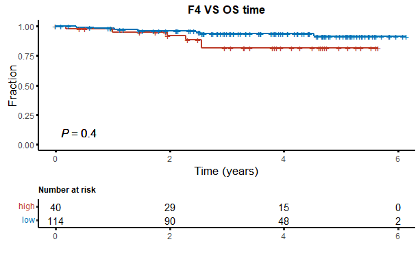

```r
#KM plot for overall survival (OS)
eachTab <- filter(testTab, factor == "Factor4") %>%
  select(value, OS, died) %>% filter(!is.na(OS))
pval <- filter(resOS, factor == "Factor4")$p
kmOS.untreat <- km(eachTab$value, eachTab$OS, eachTab$died, "F4 VS OS time",
                   stat = "maxstat", pval = pval, showTable = TRUE)
kmOS.untreat
```

KM plot for time to treatment (TTT)

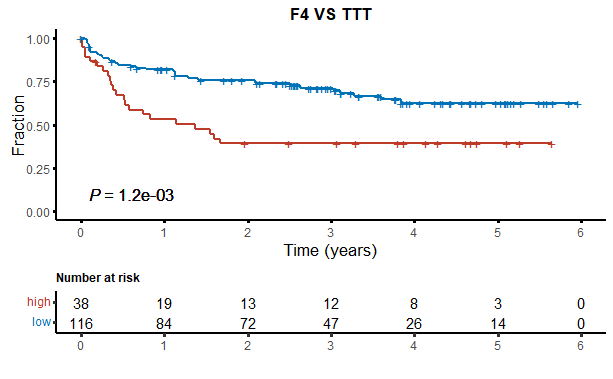

```r
eachTab <- filter(testTab, factor == "Factor4") %>%
  select(value, TTT, treatedAfter) %>% filter(!is.na(TTT))
pval <- filter(resTTT, factor == "Factor4")$p
kmTTT.untreat <- km(eachTab$value, eachTab$TTT, eachTab$treatedAfter, "F4 VS TTT",
                    stat = "maxstat", pval = pval, showTable = TRUE)
kmTTT.untreat
```

Multi-variate Cox regression

```r
#Prepare data for multi-variate Cox regression
survTab <- survival.untreated
facTab <- filter(allFactors, factor == "Factor4")
riskTab <- gene[,c("IGHV","TP53","del17p","SF3B1")] %>%
  data.frame() %>% rownames_to_column("patientID") %>%
  mutate(`TP53.del17p` = as.numeric(TP53 | del17p)) %>%
  select(-TP53, -del17p) %>%
  mutate_if(is.numeric, as.factor) %>%
  left_join(select(demographic, patientID, age, sex), by = "patientID") %>%
  mutate(age = age/10) %>%
  mutate(Factor4 = facTab[match(patientID, facTab$sample),]$value,
         IGHV = factor(IGHV, levels = c(0,1))) %>%
  dplyr::rename(IGHV_mutated = IGHV, Sex_male = sex, Age = age) %>%
  filter(!is.na(Factor4))
```

Time to treatment

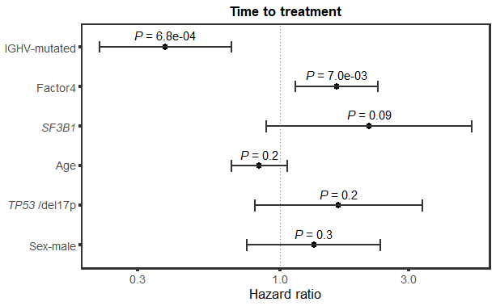

```r
resTTT <- runCox(survTab, riskTab, "TTT", "treatedAfter")

#summary(surv1)
haTTT.untreat <- plotHazard(resTTT, title = "Time to treatment")
haTTT.untreat
```

Overall survival

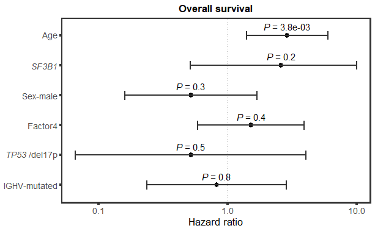

```r
resOS <- runCox(survTab, riskTab, "OS", "died")

#summary(surv1)
haOS.untreat <- plotHazard(resOS,"Overall survival")
haOS.untreat
```

Correlation between F4 and and Lymphocyte doubling time